# Gender report

Karl Cottenie, Graduate Program Coordinator Integrative Biology

2018-07-23

## Overview figure of raw data

Each figure is a scholarship of award competition, and it shows the ranks for female and male names as determined by the function “gender” in R. As a reminder lower ranks means that a student is ranked as better compared to the other applicants.

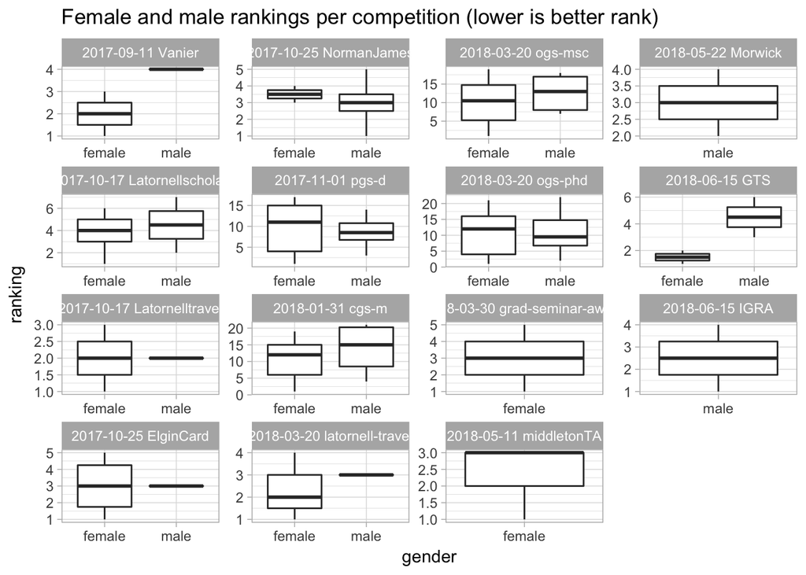

The below table provides the summary statistics for each competition.

|  | p.value | effect.size.W | samplesize.female | prop.female.female | yearaward |
| --- | --- | --- | --- | --- | --- |
| 2017-09-11 Vanier | 1.0000 | 0.0000 | 4 | 0.7500 | 2017-09-11 Vanier |
| 2017-10-17 Latornellscholar | 0.7143 | 0.4000 | 7 | 0.7143 | 2017-10-17 Latornellscholar |
| 2017-10-17 Latornelltravel | 0.6667 | 0.5000 | 3 | 0.6667 | 2017-10-17 Latornelltravel |
| 2017-10-25 ElginCard | 0.6000 | 0.5000 | 5 | 0.8000 | 2017-10-25 ElginCard |
| 2017-10-25 NormanJames | 0.4029 | 0.6250 | 6 | 0.3333 | 2017-10-25 NormanJames |
| 2017-11-01 pgs-d | 0.4442 | 0.5278 | 17 | 0.5294 | 2017-11-01 pgs-d |
| 2018-01-31 cgs-m | 0.8248 | 0.3462 | 17 | 0.7647 | 2018-01-31 cgs-m |
| 2018-03-20 latornell-travel | 0.7500 | 0.3333 | 4 | 0.7500 | 2018-03-20 latornell-travel |
| 2018-03-20 ogs-msc | 0.8145 | 0.3600 | 15 | 0.6667 | 2018-03-20 ogs-msc |
| 2018-03-20 ogs-phd | 0.4585 | 0.5185 | 21 | 0.4286 | 2018-03-20 ogs-phd |

[output cut: 5 more lines]

## Meta-analysis of all the competitions combined

How does the median effect size compares to the unbiased 50% line, where there is no difference in ranking between female and male students?

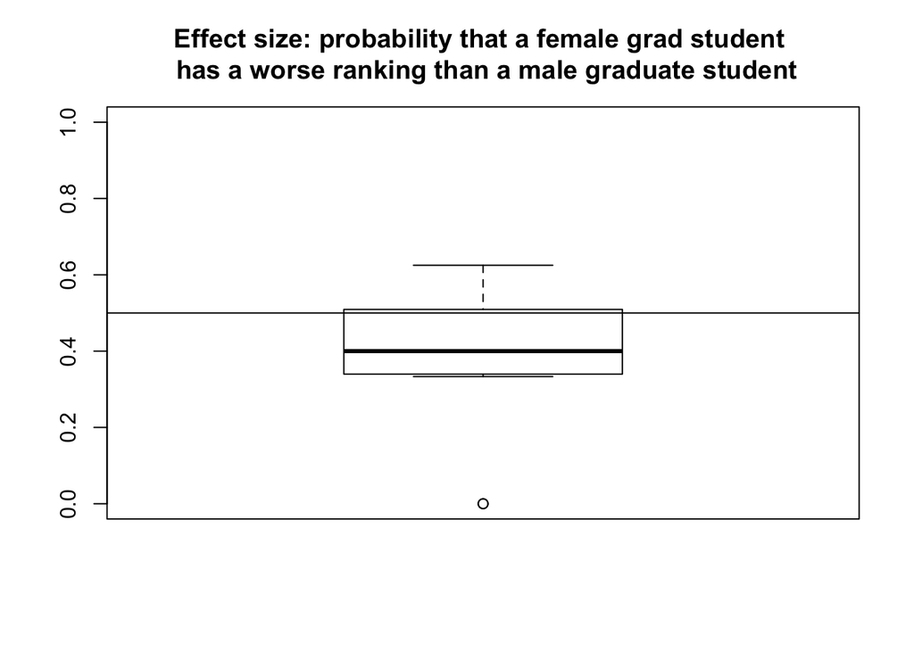

These are the p-values of all the above effect sizes. What is the distribution of each test relative to the 0.05 significance cut-off line?

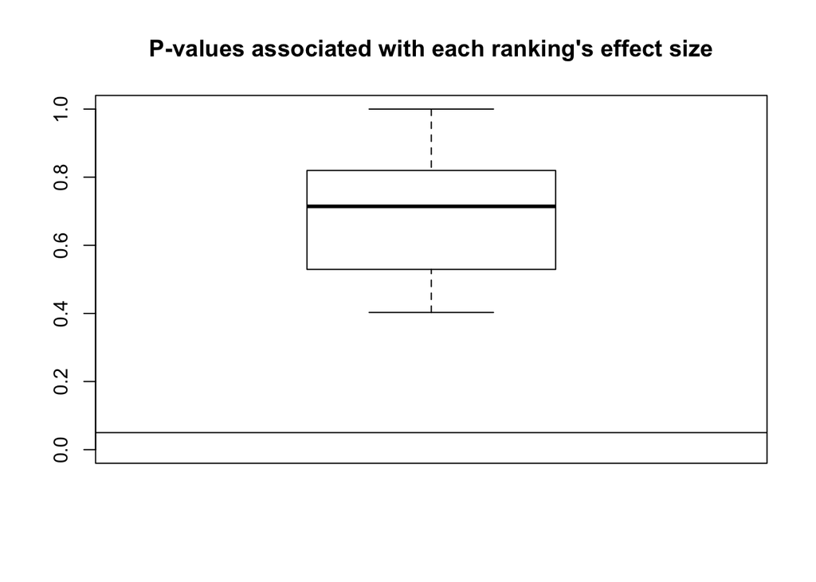

Finally, when we combine all effect sizes into one test, we can determine if there is a significant bias in effect sizes by determining if 0.5 is in the 95% confidence interval with a simple t-test:

```
One Sample t-test
```

data: summary.gender.rankings1718$effect.size.W t = -2, df = 10, p-value = 1 alternative hypothesis: true mean is greater than 0.5 95 percent confidence interval: 0.2614 Inf sample estimates: mean of x 0.3737